# Practical Machine learning project

Sarvani Pranav Gaddipati

Sunday, July 26, 2015

## PRACTICAL MACHINE LEARNING COURSE ASSIGNMENT

# INTRODUCTION:

In this project, your goal will be to use data from accelerometers on the belt, forearm, arm, and dumbell of 6 participants. They were asked to perform barbell lifts correctly and incorrectly in 5 different ways. More information is available from the website here: http://groupware.les.inf.puc-rio.br/har (see the section on the Weight Lifting Exercise Dataset).

# Findings:

1)create a report describing how you built your model 2)how you used cross validation 3)what you think the expected out of sample error is 4) why you made the choices you did 5) use your prediction model to predict 20 different test cases

# Loading the required pakages

```r
library(AppliedPredictiveModeling)
library(caret)
library(rattle)
```

```r
library(rpart.plot)
library(randomForest)
```

# Getting Data

```r
train.url<-"https://d396qusza40orc.cloudfront.net/predmachlearn/pml-training.csv"
test.url<-"https://d396qusza40orc.cloudfront.net/predmachlearn/pml-testing.csv"
if(!file.exists("./practicalmachinelearning/pml-training.csv")){

  download.file(train.url,"./practicalmachinelearning/pml-training.csv")

}
if(!file.exists("./practicalmachinelearning/pml-testing.csv")){
  download.file(test.url,"./practicalmachinelearning/pml-testing.csv")

}

train.raw<-read.csv("./practicalmachinelearning/pml-training.csv",na.strings=c("NA","#DIV/0!",""))
test.raw<-read.csv("./practicalmachinelearning/pml-testing.csv",na.strings=c("NA","#DIV/0!",""))
```

# Cleaning Data:

```r
#Dropping all the columns having NA's
train.clean<-train.raw[,colSums(is.na(train.raw))==0]
test.clean<-test.raw[,colSums(is.na(test.raw))==0]
```

```r
#Dropping first seven columns as they are unnecessary for prediction
train.clean<-train.clean[,8:length(colnames(train.clean))]
test.clean<-test.clean[,8:length(colnames(test.clean))]
```

```r
#check for nonzero covariants in the set
nvz<-nearZeroVar(train.clean,saveMetrics=TRUE)
zero.var.ind<-sum(nvz$nvz)
if(zero.var.ind>0){
  train.clean<-train.clean[,nvz$nvz==FALSE]

}
```

# Data Slicing

```r
inTrain<-createDataPartition(y=train.clean$classe,p=.6,list=FALSE)
training<-train.clean[inTrain,]
testing<-train.clean[-inTrain,]
```

# Find the out of box classification tree

```r
set.seed(999)
modelfit<-train(classe~.,data=training,method="rpart")
print(modelfit)
```

```
## CART
##
## 11776 samples
##    52 predictor
##     5 classes: 'A', 'B', 'C', 'D', 'E'
##
## No pre-processing
## Resampling: Bootstrapped (25 reps)
## Summary of sample sizes: 11776, 11776, 11776, 11776, 11776, 11776, ...
## Resampling results across tuning parameters:
##
##   cp          Accuracy   Kappa      Accuracy SD  Kappa SD
##   0.03571429  0.5125235  0.3659606  0.02075608   0.03378852
##   0.06082898  0.4020963  0.1843077  0.05739753   0.09721460
##   0.11544850  0.3297889  0.0687786  0.04190192   0.06233170
##
## Accuracy was used to select the optimal model using  the largest value.
## The final value used for the model was cp = 0.03571429.
```

```r
print(modelfit$finalModel)
```

```
## n= 11776
##
## node), split, n, loss, yval, (yprob)
##       * denotes terminal node
##
##  1) root 11776 8428 A (0.28 0.19 0.17 0.16 0.18)
##    2) roll_belt< 129.5 10729 7418 A (0.31 0.21 0.19 0.18 0.11)
##      4) pitch_forearm< -34.15 939    6 A (0.99 0.0064 0 0 0) *
##      5) pitch_forearm>=-34.15 9790 7412 A (0.24 0.23 0.21 0.2 0.12)
##       10) magnet_dumbbell_y< 439.5 8270 5944 A (0.28 0.18 0.24 0.19 0.11)
##         20) roll_forearm< 124.5 5132 3056 A (0.4 0.19 0.18 0.17 0.058) *
##         21) roll_forearm>=124.5 3138 2066 C (0.08 0.17 0.34 0.22 0.18) *
##       11) magnet_dumbbell_y>=439.5 1520  752 B (0.034 0.51 0.041 0.23 0.18) *
##    3) roll_belt>=129.5 1047   37 E (0.035 0 0 0 0.96) *
```

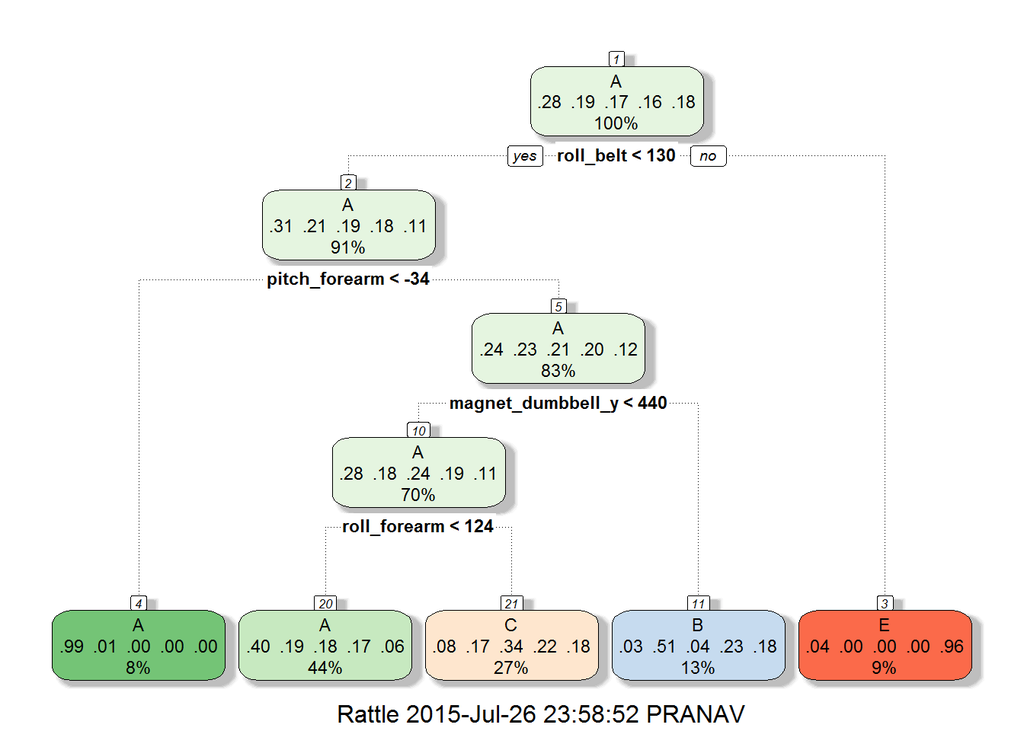

```r
library(rattle)
fancyRpartPlot(modelfit$finalModel)
```